# CCI analysis on melanoma

Yingxin Lin

08 November, 2021

CCI analysis for Sade-Feldman et al. melanoma data (10.1016/j.cell.2018.10.038).

# 1 Data and Package

```r
library(SingleCellExperiment)
library(CellChat)
library(dplyr)
library(ggplot2)
library(ggthemes)
library(ggpubr)
library(pheatmap)
library(reshape2)
library(gridExtra)
library(RColorBrewer)
ggplot2::theme_set(theme_bw() +
                     theme(axis.text.y = element_text(color = "black"),
                           axis.text.x = element_text(color = "black")))


source("scripts/cci_functions.R")
```

```r
colData <- readRDS("results/melanoma/meta_sadefeldman.rds")
metadata <- unique(colData[, c("patient", "respond", "therapy")])
metadata$prepost <- unlist(lapply(strsplit(as.character(metadata$patient), "_"), "[[", 1))
metadata$groups <- paste(metadata$prepost, metadata$respond, sep = "_")
rownames(metadata) <- metadata$patient
all_cellTypes <- sort(unique(colData$scClassify))
all_cellTypes <- all_cellTypes[!all_cellTypes %in% c("unassigned", "intermediate")]
```

# 2 Cell type annotation and data integration

Run `run_scClassify_scMerge2_melanoma.R` script ([link](https://github.com/SydneyBioX/COVID_CCI_analysis/blob/main/scripts/run_scClassify_scMerge2_melanoma.R)) to annotate the cell types using Li et al. and integrate the two melanoma datasets. The data can be downloaded from [link](https://www.maths.usyd.edu.au/u/yingxinl/wwwnb/covidCCI/data.zip).

```r
source("scripts/run_scClassify_scMerge2_melanoma.R")
```

# 3 CCI analysis

Run `run_cell_chat_sadeFeldman.R` script ([link](https://github.com/SydneyBioX/COVID_CCI_analysis/blob/main/scripts/run_cell_chat_sadeFeldman.R)) to calculate CCI scores on each patient sample using `CellChat`. Alternative, download the results from [link](https://www.maths.usyd.edu.au/u/yingxinl/wwwnb/covidCCI/melanoma.zip).

```r
source("scripts/run_cell_chat_sadeFeldman.R")
```

Loading CCI results. `cci_res` is a list of `CellChat` objects.

```r
file_list <- list.files("results/melanoma/CCI_sadefeldman/")

cci_res <- lapply(file_list, function(i) {
  readRDS(file.path("results/melanoma/CCI_sadefeldman/", i))
})
names(cci_res) <- gsub("cellchat_sadefeldman_|.rds", "", file_list)
```

Construct a pathway CCI matrix (a pathway + cell type pair times sample)

```r
pCCI_per_sample <- lapply(cci_res, pCCI_byCellType)
pCCI_all <- pCCI_summarise(pCCI_per_sample)
pCCI_all_mat <- dcast2(pCCI_all,
                          features ~ sample,
                          fun.aggregate = sum, value.var = "value")
```

Filtering the pathway CCI that are not expressed at all and expressed in less than 2 samples

```r
pCCI_all_mat <- pCCI_all_mat[rowSums(pCCI_all_mat) > 0 &
                                     rowSums(pCCI_all_mat!=0) > 2, ]
```

# 4 pCCI features selection

We used Kruskal-Wallis rank sum test to select pathway-specific CCI that distinguished responder and non-responder. The features with adjusted p-value less than 0.2 are selected. In this case study, 372 pCCI are selected.

```r
kruskal_pvalue <- selectCCIfeatures(pCCI_all_mat, metadata[colnames(pCCI_all_mat),]$respond)
selected_features <- names(kruskal_pvalue[kruskal_pvalue < 0.2])
length(selected_features)
```

```
## [1] 372
```

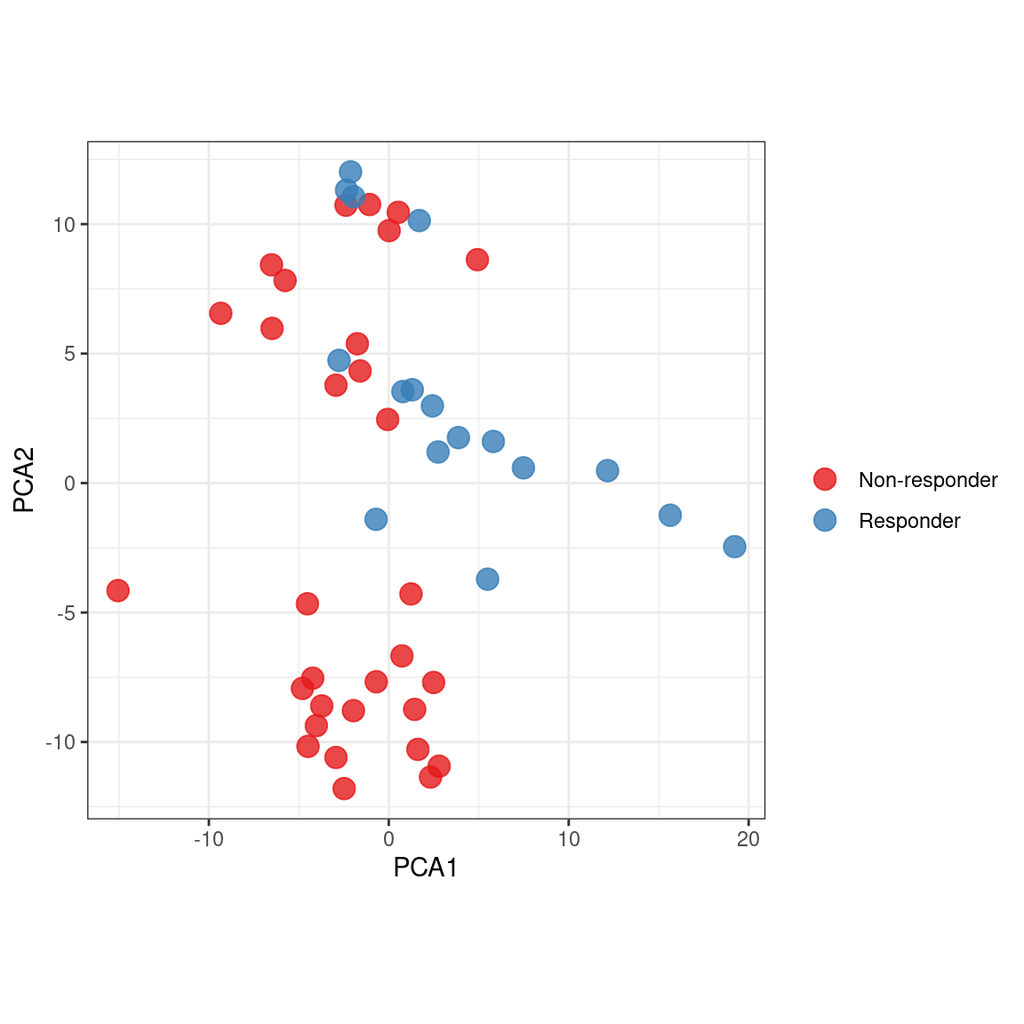

```r
pca_patient <- prcomp(t(-1/log(pCCI_all_mat[selected_features,])),
                      scale. = TRUE, center = TRUE)

ggplot(data.frame(metadata), aes(x = pca_patient$x[, 1],
                                 y = pca_patient$x[, 2],
                                 color = metadata[rownames(pca_patient$x),]$respond)) +
  geom_point(size = 4, alpha = 0.8) +
  theme_bw() +
  theme(aspect.ratio = 1) +
  xlab("PCA1") +
  ylab("PCA2") +
  labs(color = "") +
  scale_color_brewer(palette = "Set1")
```

# 5 Calculate total CCI for individual sample

Next, we calculate the total CCI for individual sample, which sums the cell-cell interaction scores between a pair of two major cell types and across all pathways.

```r
tCCI_bySample <- tCCI(pCCI_per_sample)
```

The following visualizes the tCCI of the first sample:

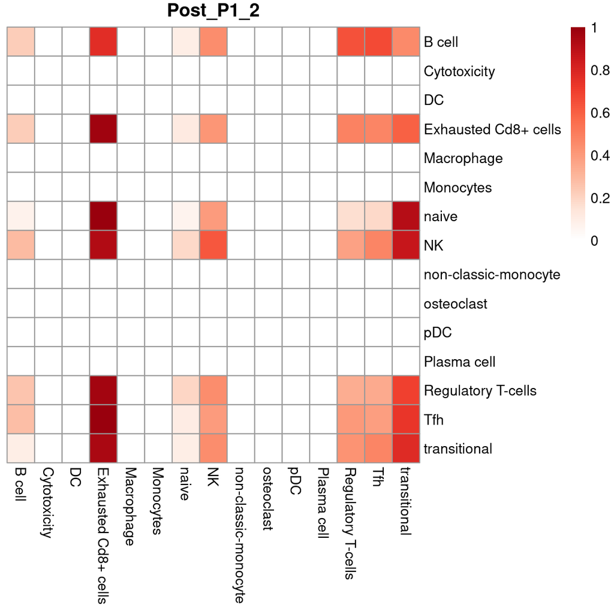

```r
plotTCCI(tCCI_bySample[[1]], title = names(tCCI_bySample)[1])
```

# 6 Calculate group CCI for each condition

Next, we calculate group specific cell-cell interaction between two cell types where groups represent any treatment of interest. For this case studies, we have 4 groups, namely: pre-responder, pre-non responder, post-responder, post-non responder.

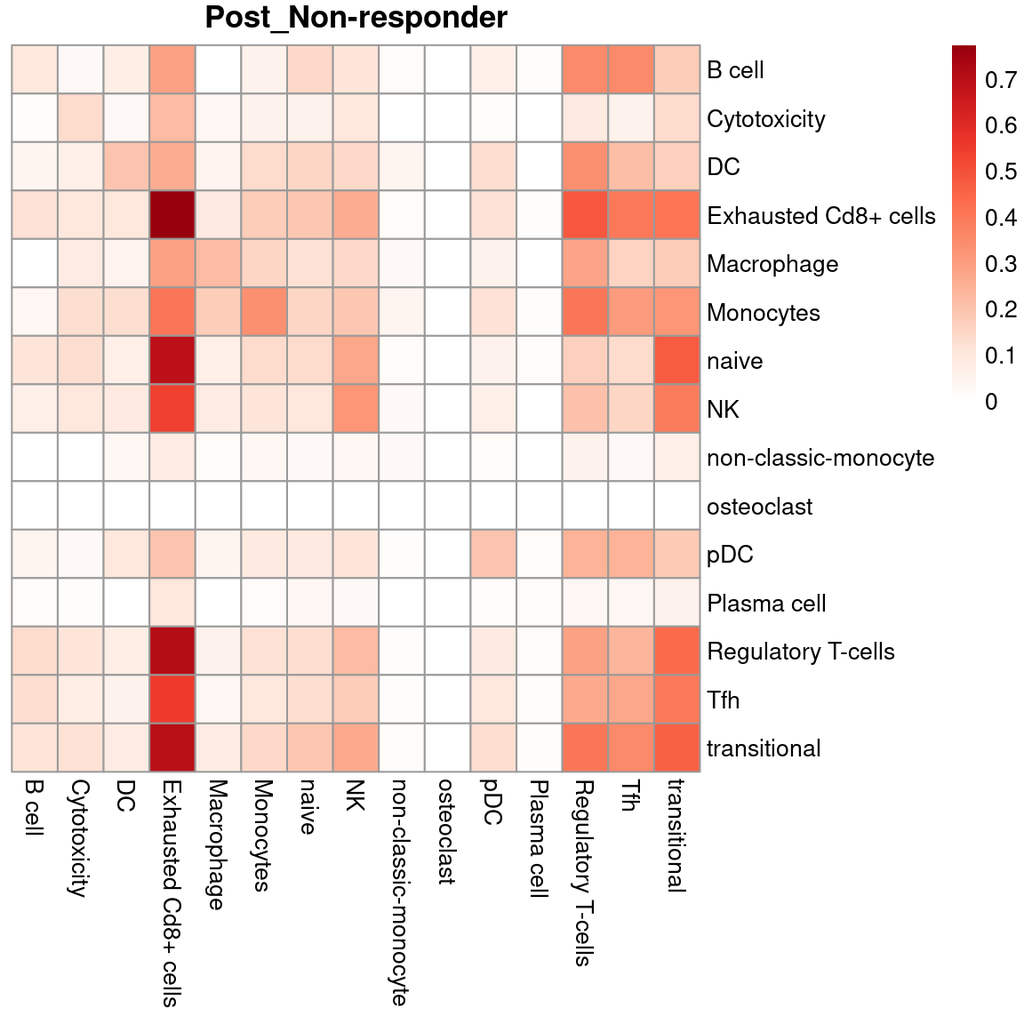

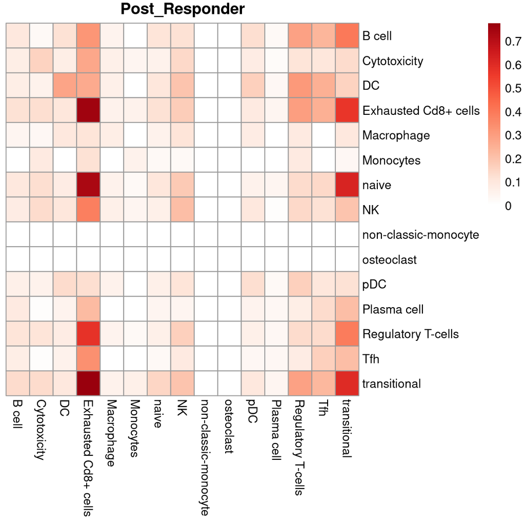

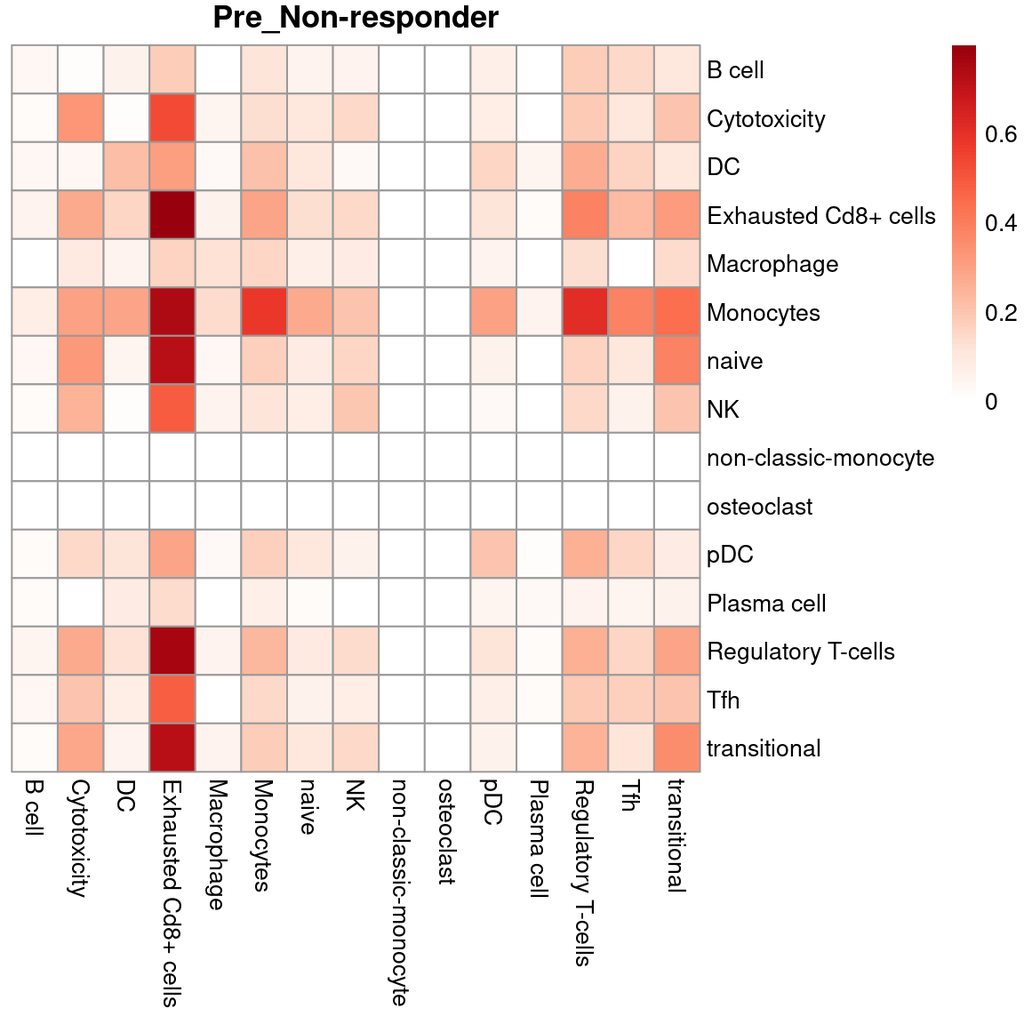

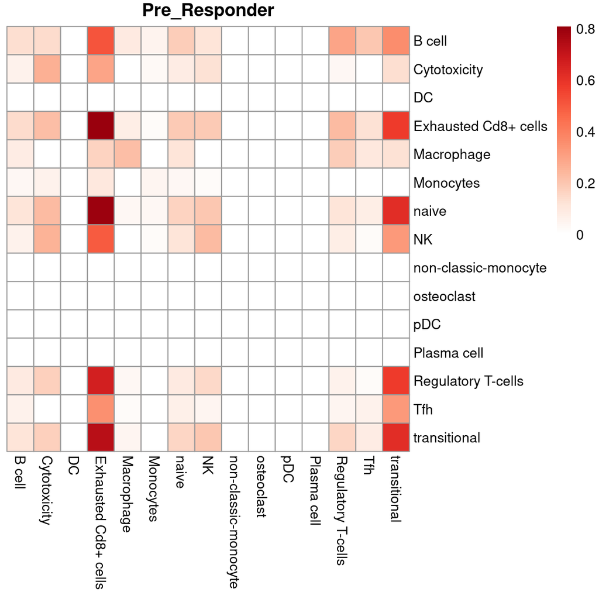

```r
groupCCI <- lapply(names(table(metadata$groups)), function(x) {
  selected_patients <- rownames(metadata)[metadata$groups == x]
  Reduce("+", tCCI_bySample[names(tCCI_bySample) %in% selected_patients])/length(selected_patients)
})

names(groupCCI) <- names(table(metadata$groups))

par(mfrow = c(2, 2))
for (i in 1:length(groupCCI)) {
  pheatmap(groupCCI[[i]], cluster_cols = FALSE,
           cluster_rows = FALSE,
           main = names(groupCCI)[i],
           color =  colorRampPalette(c("white",
                                       brewer.pal(n = 7,
                                                  name = "Reds")))(100),
           breaks = seq(0, max(groupCCI[[i]]), max(groupCCI[[i]])/100))
}
```

We can therefore investigate the difference of group CCI patterns of post- and pre- between responders and non-responders.

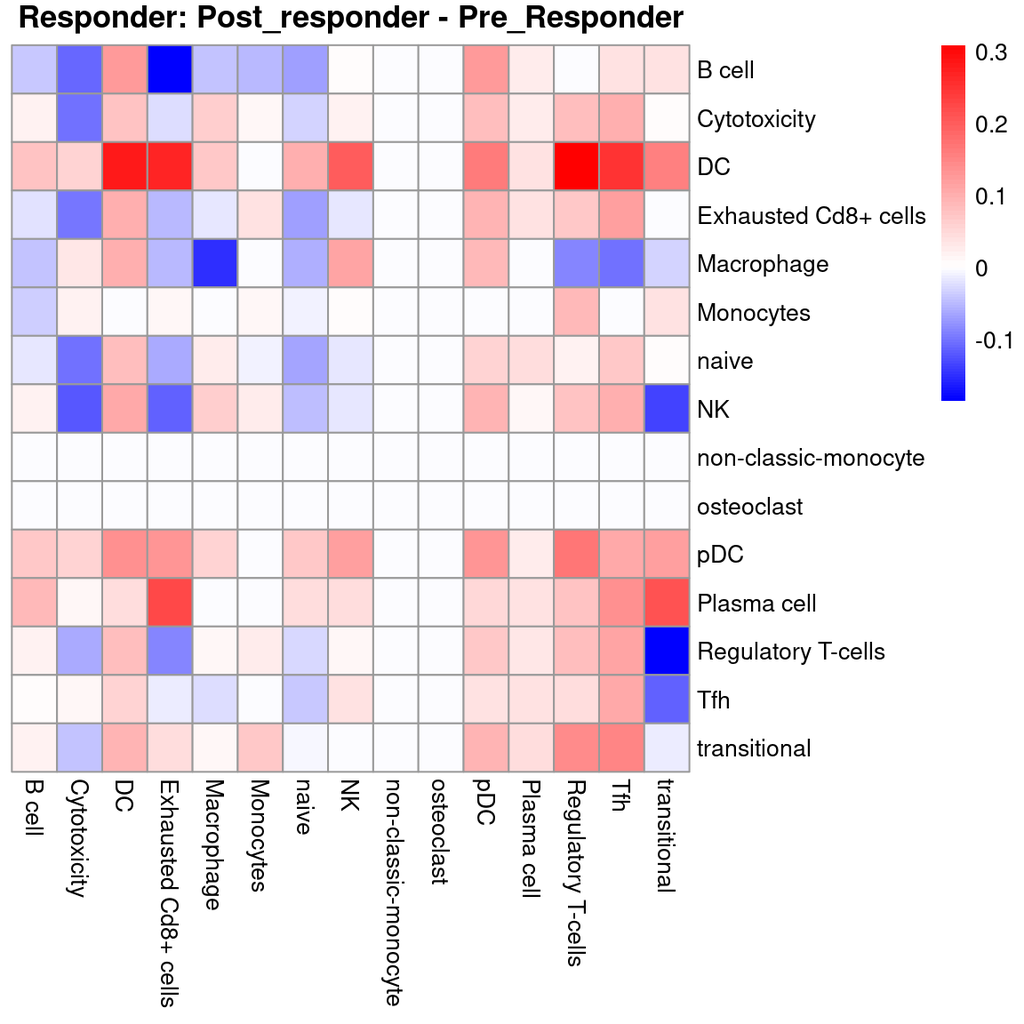

```r
aff_mat_diff_responder <- groupCCI$Post_Responder - groupCCI$Pre_Responder
pheatmap(aff_mat_diff_responder,
         cluster_cols = FALSE,
         cluster_rows = FALSE,
         color =  colorRampPalette(c("blue", "white", "red"))(100),
         breaks = c(seq(min(aff_mat_diff_responder), 0, (0 - min(aff_mat_diff_responder))/50),
                    seq(0.01, max(aff_mat_diff_responder), (max(aff_mat_diff_responder))/50)),
         main = "Responder: Post_responder - Pre_Responder",
         width = 8,
         height = 7)
```

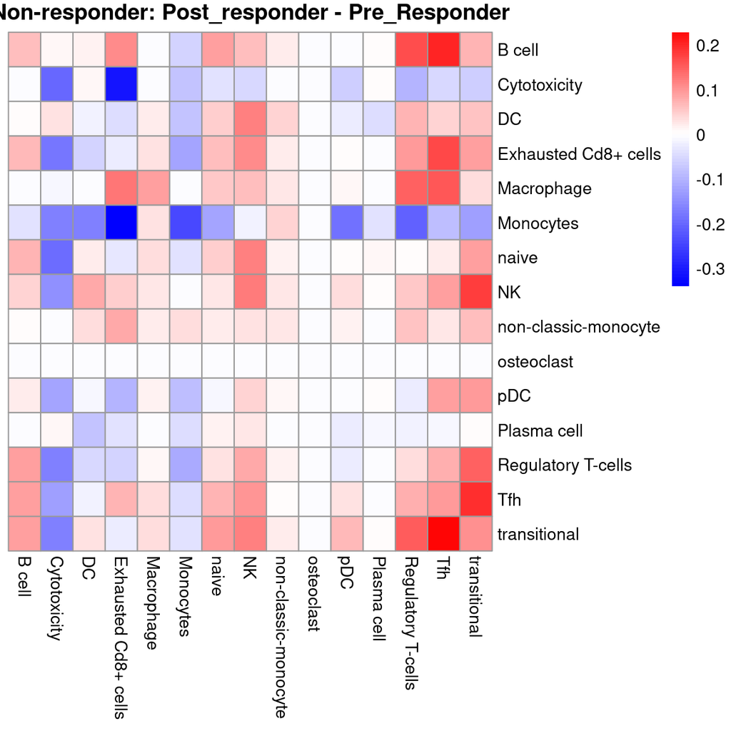

```r
aff_mat_diff_nonresponder <- groupCCI$`Post_Non-responder` - groupCCI$`Pre_Non-responder`
pheatmap(aff_mat_diff_nonresponder,
         cluster_cols = FALSE,
         cluster_rows = FALSE,
         color =  colorRampPalette(c("blue", "white", "red"))(100),
         breaks = c(seq(min(aff_mat_diff_nonresponder), 0, (0 - min(aff_mat_diff_nonresponder))/50),
                    seq(0.01, max(aff_mat_diff_nonresponder), (max(aff_mat_diff_nonresponder))/50)),
         main = "Non-responder: Post_responder - Pre_Responder",
         width = 8,
         height = 7)
```

# 7 Visualisation of pathway CCI

Zooming in pathway CCI of Exhausted Cd8+ cells to B cell, we can further investigate what are the CCI that are distingushed between the responder and non-responder

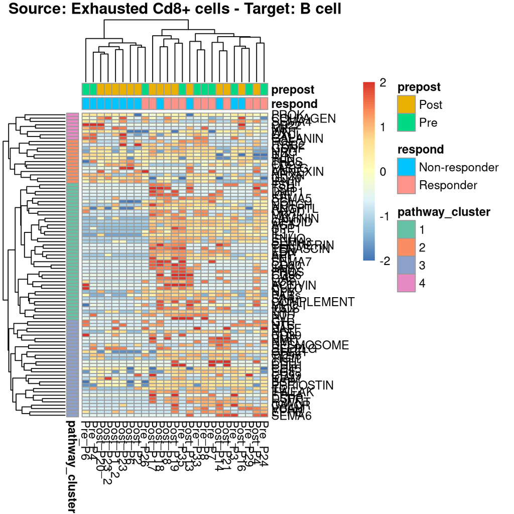

```r
plot_pathwayCCI(pCCI_all, "Exhausted Cd8+ cells", "B cell", anno_col = metadata[, c(2, 4)])
```

# 8 CCI for prediction

Finally we will predict responder and non-responder using selected pCCI features and compared the results with cell type proportion.

```r
set.seed(2021)
data <- t(-1/log(pCCI_all_mat[selected_features,]))
true <- metadata[colnames(pCCI_all_mat),]$respond
rf_predicted_top_features <- character(length(true))
for (i in 1:length(true)) {
  rf_res <- randomForest::randomForest(severity ~ ., data.frame(data[-i, ],
                                                                severity = true[-i]))
  rf_predicted_top_features[i] <- as.character(predict(rf_res, data.frame(data[i, , drop = FALSE])))


}

cat("Accuracy rate")
```

```
## Accuracy rate
```

```r
mean(rf_predicted_top_features == true)
```

```
## [1] 0.8541667
```

```r
set.seed(2021)
cell_type_prop <- table(colData$scClassify, colData$patient)
cell_type_prop <- apply(cell_type_prop, 2, function(x) x/sum(x))
data <- t(cell_type_prop)
true <- metadata[colnames(pCCI_all_mat),]$respond
rf_predicted_prop <- character(length(true))
for (i in 1:length(true)) {
  rf_res <- randomForest::randomForest(severity ~ ., data.frame(data[-i, ],
                                                                severity = true[-i]))
  rf_predicted_prop[i] <- as.character(predict(rf_res, data.frame(data[i, , drop = FALSE])))


}

mean(rf_predicted_prop == true)
```

```
## [1] 0.7291667
```